# ExeterUQ MOGP - History Matching

Danny Williamson

06/05/2020

### Preliminaries

First we specify the directory where mogp is installed so that the python is correctly imported. Your directory will be different from mine.

```r
mogp_dir <- "~/Dropbox/BayesExeter/mogp_emulator"
```

```r
setwd('..')
source("BuildEmulator/BuildEmulator.R")
```

```
## far library : Modelization for Functional AutoRegressive processes
```

```
## version 0.6-4 (2014-12-07)
```

[output not shown]

```
## See https://github.com/NCAR/Fields for
##  an extensive vignette, other supplements and source code
```

[output not shown]

```r
source("HistoryMatching/HistoryMatching.R")
source("HistoryMatching/impLayoutplot.R")
```

We load the same data looked at in the tutorial on building emulators.

```r
load("ConvectionModelExample.Rdata")
head(tData)
```

```
##          A_U  A_EPSILON         A_T       Noise
## 1 -0.7112332  0.5198038  0.56237588 -0.03849208
## 2 -0.2465941 -0.4163290  0.88555390 -0.02695154
## 3  0.3333848 -0.1316253  0.30027685 -0.04939970
## 4  0.4462722  0.8817862  0.78243180  0.01830642
## 5 -0.9065298 -0.3119412 -0.07690085 -0.04815524
## 6 -0.4732543  0.3305641 -0.98112145 -0.02420066
##   WAVE1_AYOTTE_24SC_zav.400.600.theta_5_6 WAVE1_AYOTTE_24SC_Ay.theta_5_6
## 1                                306.1641                     -0.3697345
## 2                                306.7235                     -0.5671676
## 3                                306.6203                     -0.4999037
## 4                                306.3918                     -0.3919627
## 5                                306.1552                     -0.3685847
## 6                                305.6225                     -0.3485485
##   WAVE1_AYOTTE_24SC_zav.400.600.WND_5_6
## 1                              13.82073
## 2                              12.25888
## 3                              11.82482
## 4                              11.94844
## 5                              14.73021
## 6                              13.17205
```

Build an emulator.

```r
TestEm <- BuildNewEmulators(tData, HowManyEmulators = 3)
```

```
## [1] "Max reduction is 0.141510566268957 using A_EPSILON"
## [1] "Max reduction is 0.0719279431890675 using A_U"
## [1] "Max reduction is 0.0593934956606317 using A_T"
## [1] "Max reduction is 0.0841015596079704 using A_EPSILON"
## [1] "Max reduction is 0.0215815680504046 using A_EPSILON"
## [1] "Max reduction is 0.0221974794878812 using A_EPSILON"
## [1] "Noise fitted, stopping algorithm"
##
## Call:
## lm(formula = WAVE1_AYOTTE_24SC_zav.400.600.theta_5_6 ~ A_EPSILON +
##     I(A_EPSILON^2) + I(A_EPSILON^3) + I(A_EPSILON^4) + A_U +
##     A_T + I(A_U * A_EPSILON) + I(A_T * A_EPSILON) + I(A_T * A_U),
##     data = tData)
##
## Residuals:
##      Min       1Q   Median       3Q      Max
## -0.15059 -0.06624  0.01615  0.05931  0.15216
##
## Coefficients:
##                     Estimate Std. Error  t value Pr(>|t|)
## (Intercept)        306.35982    0.03461 8852.437  < 2e-16 ***
## A_EPSILON           -0.31275    0.08180   -3.824  0.00106 **
## I(A_EPSILON^2)      -0.19500    0.21788   -0.895  0.38145
## I(A_EPSILON^3)      -0.43915    0.12490   -3.516  0.00217 **
## I(A_EPSILON^4)       0.83401    0.24582    3.393  0.00289 **
## A_U                  0.30423    0.03234    9.409 8.73e-09 ***
## A_T                  0.33990    0.03172   10.715 9.78e-10 ***
## I(A_U * A_EPSILON)  -0.08042    0.05404   -1.488  0.15233
## I(A_T * A_EPSILON)  -0.08069    0.06159   -1.310  0.20500
## I(A_T * A_U)        -0.03824    0.06560   -0.583  0.56648
## ---
## Signif. codes:  0 '***' 0.001 '**' 0.01 '*' 0.05 '.' 0.1 ' ' 1
##
## Residual standard error: 0.09867 on 20 degrees of freedom
## Multiple R-squared:  0.9731, Adjusted R-squared:  0.961
## F-statistic: 80.31 on 9 and 20 DF,  p-value: 1.004e-13
##
##
## Call:
## lm(formula = WAVE1_AYOTTE_24SC_zav.400.600.theta_5_6 ~ A_EPSILON +
```

[output cut: 205 more lines]

```
## A_T                            -0.01237    0.01781  -0.694 0.496884
## I(A_EPSILON * A_U)             -0.39676    0.02984 -13.295 2.07e-10 ***
## I(A_T * A_U)                    0.13192    0.03907   3.376 0.003589 **
## I(A_EPSILON * A_EPSILON * A_U)  0.39776    0.05808   6.848 2.83e-06 ***
## I(A_EPSILON * A_T * A_U)        0.10485    0.08882   1.180 0.254096
## ---
## Signif. codes:  0 '***' 0.001 '**' 0.01 '*' 0.05 '.' 0.1 ' ' 1
##
## Residual standard error: 0.05457 on 17 degrees of freedom
## Multiple R-squared:  0.9985, Adjusted R-squared:  0.9974
## F-statistic: 927.6 on 12 and 17 DF,  p-value: < 2.2e-16
##
## [1] "1 I(A_EPSILON * A_T * A_U)"
## [1] "2 I(A_EPSILON^2)"
## [1] "3 I(A_T * A_U)"
```

```
## [1] "4 A_T"
## [1] "5 I(A_EPSILON * A_EPSILON * A_U)"
## [1] "6 I(A_U^5)"
## [1] "7 I(A_U^4)"
## [1] "8 I(A_EPSILON * A_U)"
##
## Call:
## lm(formula = WAVE1_AYOTTE_24SC_zav.400.600.WND_5_6 ~ A_U + I(A_U^2) +
##     I(A_U^3) + A_EPSILON, data = tData)
##
## Residuals:
##      Min       1Q   Median       3Q      Max
## -0.70366 -0.10215  0.00988  0.08980  0.42528
##
## Coefficients:
##             Estimate Std. Error t value Pr(>|t|)
## (Intercept) 12.00348    0.06088 197.177  < 2e-16 ***
## A_U         -0.75201    0.16969  -4.432 0.000163 ***
## I(A_U^2)     1.44290    0.13363  10.798 6.66e-11 ***
## I(A_U^3)    -1.24241    0.25153  -4.939 4.36e-05 ***
## A_EPSILON    0.32197    0.07089   4.542 0.000122 ***
## ---
## Signif. codes:  0 '***' 0.001 '**' 0.01 '*' 0.05 '.' 0.1 ' ' 1
##
## Residual standard error: 0.2234 on 25 degrees of freedom
## Multiple R-squared:  0.9624, Adjusted R-squared:  0.9564
## F-statistic:   160 on 4 and 25 DF,  p-value: < 2.2e-16
```

### History matching example

The history matching codes we have included target multiple implausibility, plotting, and analyses over many waves. They are also generalised for basis emulation which will be added to this repository soon. We do not yet have a simple function `historyMatching()` that implements the steps below with an sequence of waves of mogp emulators, so we take you through a step by step use of our history matching codes for a single wave below. Something more general that wraps the steps below for multiple waves will be written in a future update.

The discrepancy variances for each output, the observations and the error on the observations are required for history matching.

```r
tDisc <- c(0.15,0.05,0.1)
tObs <- c(306, 0.45, 12.4)
tObsErr <- c(0.15,0.05,0.1)
```

We generate a random sample in the parameter space and calculate the implausibility across all of the outputs simultaneously. We have included a time stamp to show how fast this is for 1 million samples thanks to mogp.

```r
sample_size <- 1000000
nparam <- length(names(TestEm$fitting.elements$Design))
Xp <- as.data.frame(2*randomLHS(sample_size, nparam)-1)
names(Xp) <- names(TestEm$fitting.elements$Design)
system.time(Timps <- ImplausibilityMOGP(NewData=Xp, Emulator=TestEm, Discrepancy=tDisc, Obs=tObs, ObsErr=tObsErr))
```

```
##    user  system elapsed
##  10.203   3.502   4.560
```

We collect the inputs and the implausibilities for each output into a matrix

```r
ImpData_wave1 = cbind(Xp, Timps)
```

and define some of the elements required for history matching. We need the number of outputs that can exceed the implausibility cutoff, the cutoff itself (often 3 by default in the literature), and the standard parameters of the model mapped to [-1,1].

```r
VarNames <- names(Xp)
valmax = 0 #how many outputs can be above the implausibility cut off?
cutoff_vec <- 3 #the implausibility cut off
param.defaults.norm=rep(0,nparam) #the default parameters of the model (on [-1,1])
```

The sampled implausibilities are then used to find NROY space and to create matrices for plotting 2D projections of parameter space.

```r
ImpListM1 = CreateImpList(whichVars = 1:nparam, VarNames=VarNames, ImpData=ImpData_wave1, nEms=TestEm$mogp$n_emulators, whichMax=valmax+1)
NROY1 <- which(rowSums(Timps <= cutoff_vec[1]) >= TestEm$mogp$n_emulators -valmax)
length(NROY1)/dim(Xp)[1]
```

```
## [1] 0.534071
```

NROY density plots

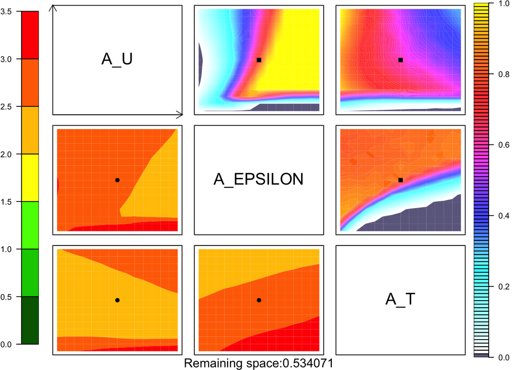

```r
imp.layoutm11(ImpListM1,VarNames,VariableDensity=FALSE,newPDF=FALSE,the.title=paste("InputSpace_wave",WAVEN,".pdf",sep=""),newPNG=FALSE,newJPEG=FALSE,newEPS=FALSE,Points=matrix(param.defaults.norm,ncol=nparam))
mtext(paste("Remaining space:",length(NROY1)/dim(Xp)[1],sep=""), side=1)
```